# Final Project

### Group 3

#### Group Members

- Abhijeet Manohar
- Alex Smith
- Steven Hizmi
- Yumian Cui

## Introduction

In today’s modern age of intense international competition, our group wanted to better understand how national expenditure on education correlated to international university rankings, if at all. To that end, we found data sets that gave us international university rankings, as well as data sets that gave us national expenditure on education in 36 different countries.

After much analysis, we found that national expenditure on education is not correlated with that country’s average university world ranking. In technical terms, we do not have sufficient evidence to reject the null hypothesis that a country’s average university world ranking is not correlated at all with that country’s expenditure on higher education.

## Background

### Finding The Data

Our team began by searching Kaggle.com for data on international university rankings and national expenditure on education. On Kaggle, we found Myles O’Neill’s repository of World University Rankings data.[^1] From this repository, we used three data sets.

#### University Ranking Data Sets

For the first of these data sets, we used the Center for World University Rankings (CWUR) data.[^2] There is information for the years 2012, 2013, 2014, and 2015. In 2014 and 2015, 1,000 Universities were ranked, unlike the previous two years that ranked the top 100 Universities instead. The data contains information such as the rank of the institution, name, country, rank within the country, etc.

Next, we have a data set from the Academic Ranking of World Universities (ARWU), in which the Shanghai Ranking Consultancy gives their own list of University rankings.[^3] The data includes information from the year 2005 to 2015. The dataset contains the world rank of the institution, name, rank within country, ‘score’ of University, etc.

Our last data set of world ranks was obtained from Times Higher Education World University Ranking (Times Ranking).[^4] The data includes information from 2011 through 2016. Unlike the ShanghaiRanking, Times Ranking allows the possibility of ‘tying’, where a University’s rank can be shared with another University, but only occurs outside of the top 100 Universities ranked. The data includes the same information as the previous dataset, but includes scores that are broken down; such as an international score, research score, citation score, income score, and total score. Not all countries are in each dataset, as it depends on the institution that created the ranking.

### Preparing The Data

The first step with our data was to clean and prepare it for analysis.

As mentioned above, we decided to only consider national spending on higher education in 2011 and 2016. These are the years we found spending data to be the most recent and complete from the Organization for Economic Cooperation and Development (OECD).

Regarding the three different ranking systems, our goal was to combine them in some way, so that any biases in the rankings could be averaged out. To that end, we decided on a three step process for merging the rankings:

1. Group each university by the country it is in.
2. Find the average ranking for each country in each data set.
3. Find the average country ranking between the three data sets.

We decided on this process because there were too many semantic differences in the university names between the three rankings (for example, the CWUR and Times data refer to our school as “University of Wisconsin-Madison”, while the Shanghai data refer to “University of Wiscosin - Madison”. Since the spacing is different, the terms would not match). Without manually ensuring each school was listed the same in each data set, we could not ensure each university matched. However, the country names were easy to confirm as exactly the same between data sets. Thus, by finding the average rank of each country per data set, we could avoid the issue of university names not matching between data sets.

It is also important to note that we decided to focus our attention on the top 100 universities from each ranking system for each year in which data was provided, and no universities below the top 100. The reason for this is that each ranking organization treated institutions below the top 100 differently (the CWUR data ranked the top 1000 universities, while the Shanghai data gave a range of rankings for those ranked below 100, and the Times data allowed for tied scores below the 100 ranking). In order to avoid any errors that might arise from these incongruities, we selected only the top 100 universities from each data set.

A final note regarding the cleaning of our data is that the Shanghai data set did not include a column for the university’s country. However, with us only considering the top 100 institutions from that data set, it was more reasonable for us to add this column to the data set manually. We did so by pulling university and country pairs from the CWUR data (as the largest data set, it had the most pairs), and matching university names with the Shanghai data. While there were a number of semantic disagreements between the two data sets, we manually overcame them and moved forward.

Having cut the data from each ranking agency down to their top 100 universities in each year for which data was available, and found each country’s average rank, we merged this data together using country and year as a key and found the average world ranking of each country’s institutions throughout all the years for which ranking data was included.

We then filtered out countries from this data that were not members of the OECD (as we only had data on OECD member countries), and adjoined to this remaining list the education spending of each country in 2011 and 2016.

We now had a data table from which we could properly do analysis. The first ten rows of this table are included to further elucidate understanding of our methods:

```
## # A tibble: 10 x 5
##    country             year average_world_rank gdp_percent_2011 gdp_percent_2016
##    <chr>              <dbl>              <dbl>            <dbl>            <dbl>
##  1 Israel              2011               14.2             1.65            0.788
##  2 Russian Federation  2011               19.2             1.39            0.733
##  3 Ireland             2011               21.2             1.48            0.574
##  4 Korea, Republic of  2011               25.4             2.62            0.654
##  5 United States       2011               28.0             2.70            0.852
##  6 Belgium             2011               30.4             1.41            1.23
##  7 France              2011               32.6             1.49            1.12
##  8 Switzerland         2011               33.6            NA               1.27
##  9 New Zealand         2011               36.2             1.51            0.882
## 10 United Kingdom      2011               36.6             1.23            0.494
```

Our table has a column with the country name, a column that pairs each country with a year in which the average world rank was calculated, a column for the average world rank for that year, a column for the percentage of GDP spent by each country in 2011 on higher education, and a column for the percentage of GDP spent by each country in 2016 on higher education.

“NA” values represent years in which spending data was not available due to the country not being a current member of the OECD.

## Analysis

This brings us to the actual graphing of our work. We began by graphing 2011 rankings against 2011 spending, just to see what association the two may have:

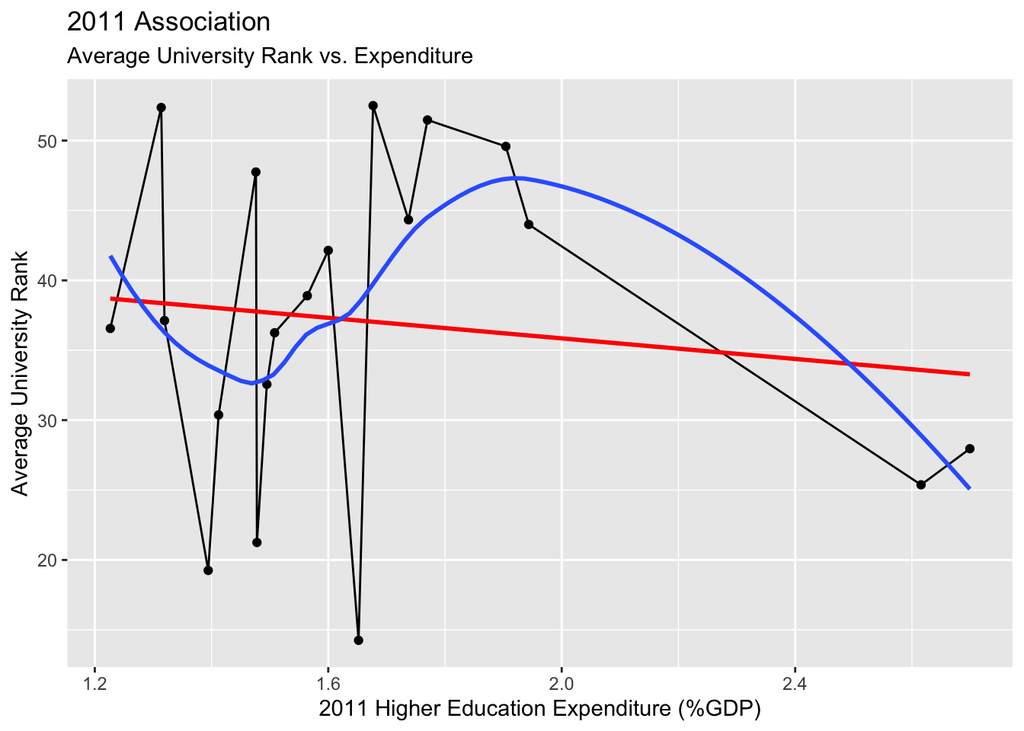

Note that we hypothesize an increase in spending leads to a decrease in rank (a rank closer to #1), and this graph seems to provide evidence in support of that hypothesis (further discussion of the regression occurs in the Discussion section).

We wanted to compare this 2011 rank vs. 2011 expenditure graph to a 2016 rank vs. 2016 expenditure graph, and so created the following:

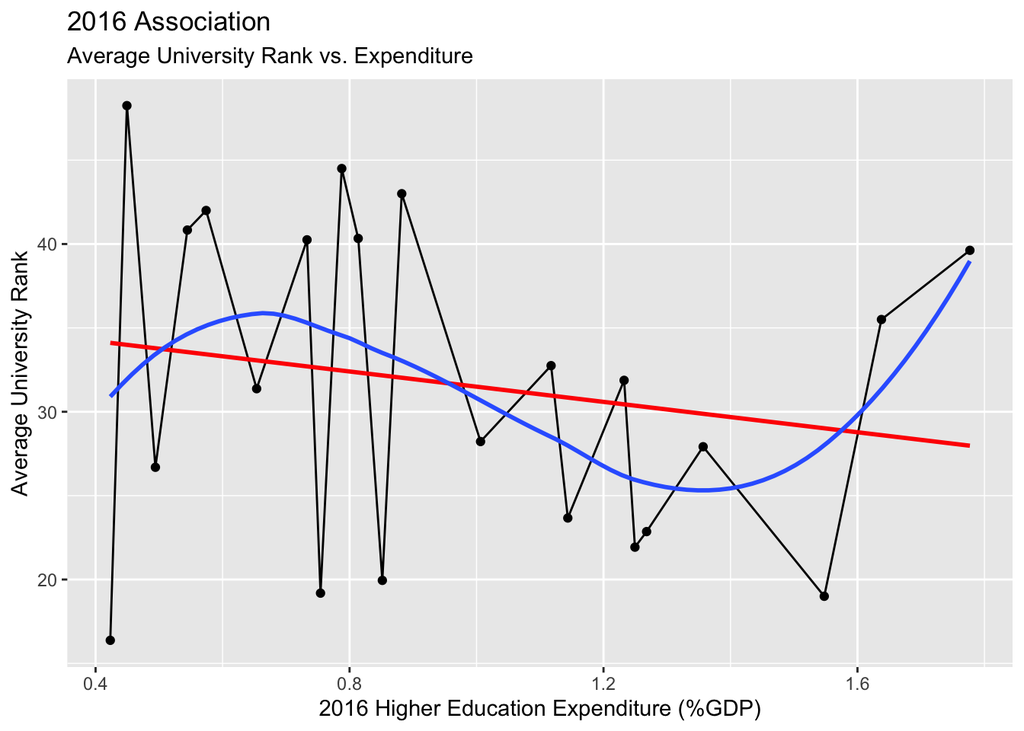

This 2016 graph of associations seems to agree with the 2011 graph of associations (further discussion of the regression occurs in the Discussion section).

We had one final question from our data: what if there was a delayed effect? That is, what if spending in 2011 had a correlation with a rank improvement in a year later than 2011 that was stronger than the correlation within that same year? Was there any evidence of a delayed correlation, of spending in 2011 really making a difference in another year? We took a look:

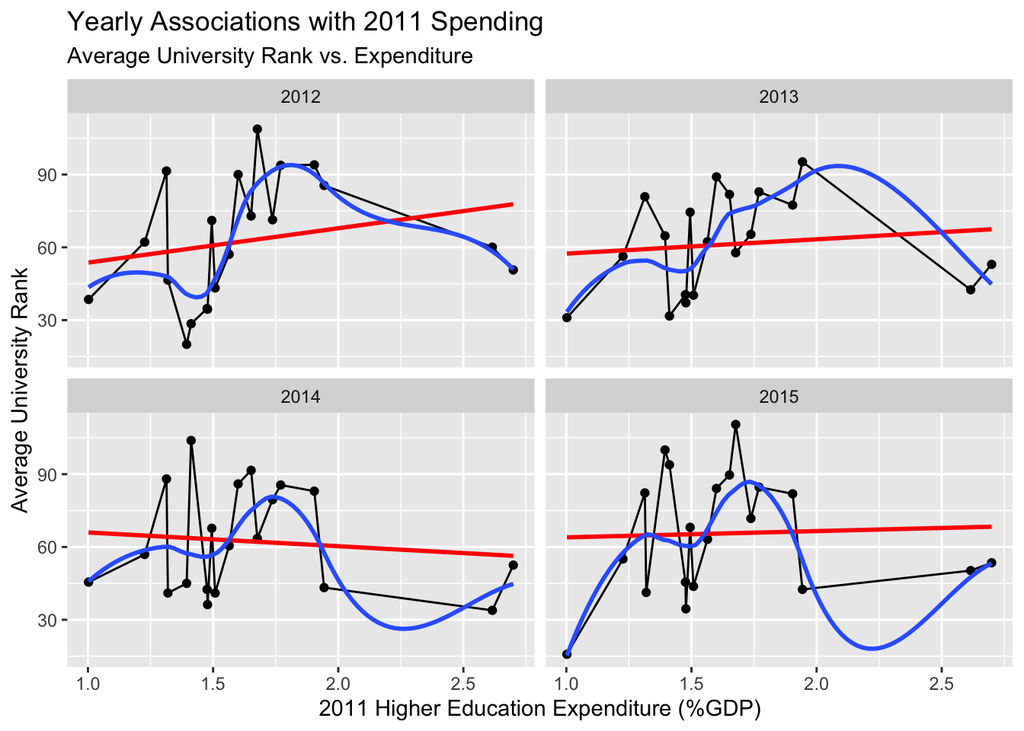

This graph compares each country’s 2011 higher education expenditure amount (as a percentage of GDP) to its average university ranking for each year from 2012 to 2015 (further discussion of the regression occurs in the Discussion section).

With our graphical analysis concluded, we needed to see just how strong any correlations were. Using least mean squares analysis, we calculated the estimate of the slope for each of the above graphs, as well as a p-value for that estimate. We put these values into the following table:

```
## # A tibble: 5 x 3
##   year  estimate_slope p_value
##   <chr>          <dbl>   <dbl>
## 1 2011           -3.68   0.610
## 2 2012           14.2    0.330
## 3 2013            5.91   0.618
## 4 2014           -5.67   0.650
## 5 2015            2.59   0.857
```

This table shows the estimated slope for how 2011 spending correlates to each years average ranking, and an estimated p-value for that estimated slope (further discussion of this least mean squares analysis occurs in the Discussion section).

### Another Computation Method

After filtering the countries we have in Universities.tsv (the one in which has the number of universities in each ranking range for countries) [^6], we end up with 12 countries and plot their ranking ratio score against their expenditure from year 2013 to 2016 respectively. Below are scatter plots we did:

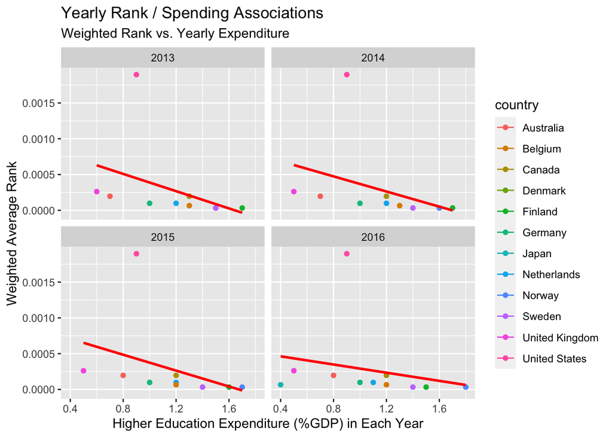

```
## # A tibble: 4 x 3
##   year  estimate_slope p_value
##   <chr>          <dbl>   <dbl>
## 1 2013       -0.000603   0.229
## 2 2014       -0.000529   0.258
## 3 2015       -0.000555   0.312
## 4 2016       -0.000286   0.518
```

## Discussion

From our analysis, we conclude that national expenditure on education does not strongly correlate with a country’s average university world ranking.

We make this conclusion based on the large p-values for the LMS analysis of average world ranking against expenditure. None of the calculated p-values are below 0.1, and thus none of the estimated slope values are statistically significant.

This conclusion is further supported when weighing country ranks against the number of universities in that country. The fact that these p-values are also large further leads us to accept a null hypothesis, that there is no correlation.

While we trust in our analysis, we do recognize there are a number of areas for improvement, and also that some of our assumptions may be faulty. It is important to note from the beginning that no data source is ever perfectly clean, or composed of all the data we might like to have. Since we only had expenditure datas for certain countries, other countries with exceptional universities were left out of our analysis, such as China and India. As far as our assumptions are concerned, averaging the rankings between three organizations may have some inherent flaws to it, since each organization uses different criteria to create their rankings. Some of this could be overcome by comparing expenditure to each criteria, and seeing which of those criteria is most or least affected by expenditure. This is yet another avenue for further study.

In conclusion, there is much to be learned about how expenditure affects worldwide university rankings, but we feel confident in saying that expenditure is not the most conclusive predictor of an educational institution’s success.

## References

[^1]: https://www.kaggle.com/mylesoneill/world-university-rankings
[^2]: https://cwur.org/
[^3]: http://www.shanghairanking.com/index.html#
[^4]: https://www.timeshighereducation.com/world-university-rankings
[^5]: https://nces.ed.gov/programs/digest/d14/tables/dt14_605.20.asp
[^6]: http://www.webometrics.info/en/distribution_by_country